# Tutorial for main functions in MonotonicityTest package

Dylan Huynh

2025-01-03

This package provides functions to visualize data and perform monotonicity tests using nonparametric and bootstrap-based methods. The goal is to test if some response variable `Y` is strictly increasing, or decreasing with larger values of some predictor `X`. A detailed explanation of this test is available in Hall and Heckman (2000, The Annals of Statistics, doi:10.1214/aos/1016120363).

The main functions provided are `monotonicity_test` and `create_kernel_plot`. The function `monotonicity_test` conducts a nonparametric bootstrap test for monotonicity between two numeric vectors `X` and `Y`. The `create_kernel_plot` provides a visualization of the kernel regression we will do based on a specific kernel bandwidth.

We will use this to analyze the `Wage` dataset from `ISLR` which contains wage data for 3000 male workers. We use this dataset as we recommend having 300+ points for the kernel estimation being used by the test to be accurate.

## Preparing Data & Loading Libraries

```r
# If not installed,
# install.packages("ISLR")
# install.packages("MonotonicityTest")

# Loading Libraries
library(MonotonicityTest)
library(ISLR)

# Loading data
data(Wage)
data <- Wage

head(data)
```

```
##        year age           maritl     race       education             region
## 231655 2006  18 1. Never Married 1. White    1. < HS Grad 2. Middle Atlantic
## 86582  2004  24 1. Never Married 1. White 4. College Grad 2. Middle Atlantic
## 161300 2003  45       2. Married 1. White 3. Some College 2. Middle Atlantic
## 155159 2003  43       2. Married 3. Asian 4. College Grad 2. Middle Atlantic
## 11443  2005  50      4. Divorced 1. White      2. HS Grad 2. Middle Atlantic
## 376662 2008  54       2. Married 1. White 4. College Grad 2. Middle Atlantic
##              jobclass         health health_ins  logwage      wage
## 231655  1. Industrial      1. <=Good      2. No 4.318063  75.04315
## 86582  2. Information 2. >=Very Good      2. No 4.255273  70.47602
## 161300  1. Industrial      1. <=Good     1. Yes 4.875061 130.98218
## 155159 2. Information 2. >=Very Good     1. Yes 5.041393 154.68529
## 11443  2. Information      1. <=Good     1. Yes 4.318063  75.04315
## 376662 2. Information 2. >=Very Good     1. Yes 4.845098 127.11574
```

We are particularly interested in two variables,

- **`age`**: Age of the worker
- **`wage`**: Workers raw wage

We would expect `wage` to monotonically increase with the age, and want to analyze this.

## Choosing Kernel Bandwidth

The first thing we need to do is choose an appropriate kernel bandwidth using the `create_kernel_plot` function.

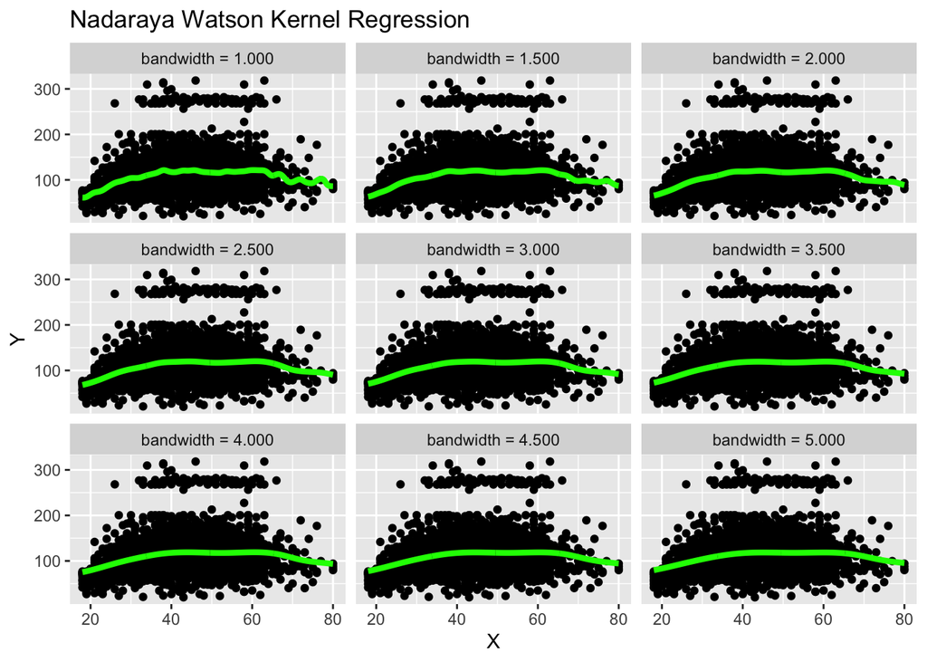

```r
X <- data$age
Y <- data$wage

create_kernel_plot(X, Y, bandwidth = seq(1, 5, by=0.5), nrow=3)
```

From here, `bandwidth=3` seems like a fitting choice for the bandwidth.

## Performing Test

```r
seed <- 42
set.seed(seed)

bandwidth <- 3
ncores <- 4
boot_num <- 20

res <- monotonicity_test(
  X,
  Y,
  ncores = ncores,
  boot_num = boot_num,
  bandwidth = bandwidth,
  negative= FALSE,
  seed = seed,
  check_m = TRUE  # Run test for different values of m, has no impact on runtime performance
)

print(res)
```

```
##
## P-Value: 0.000
## T-Statistic: 166.384
##
## Call 'summary()' for more information.
```

```r
summary(res)
```

[output not shown]

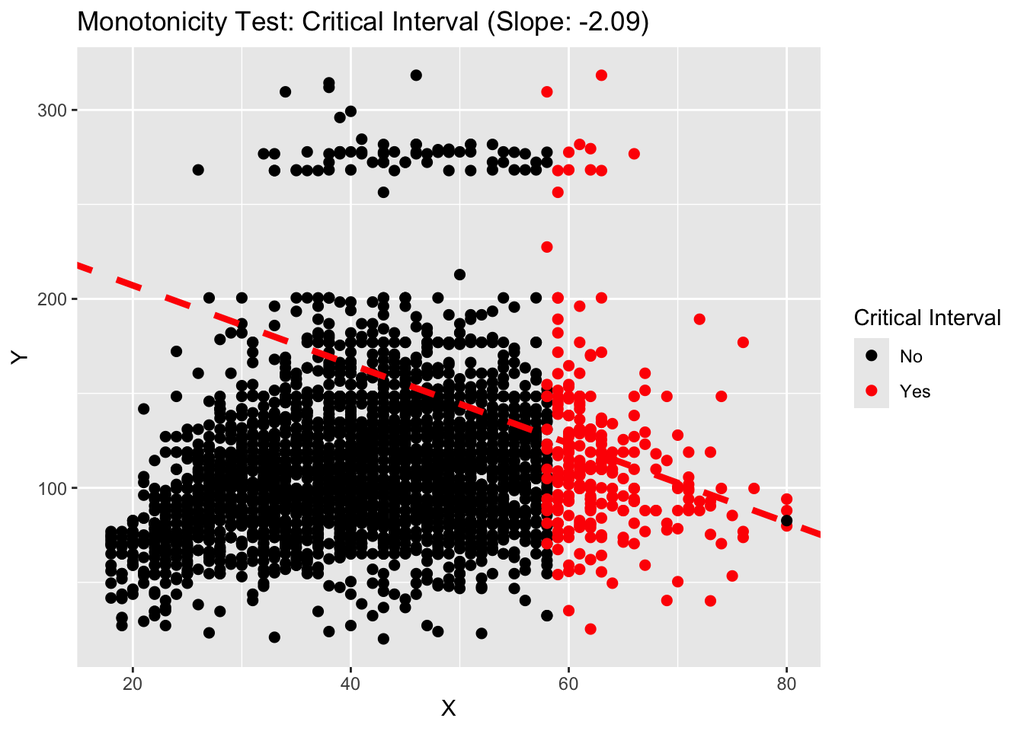

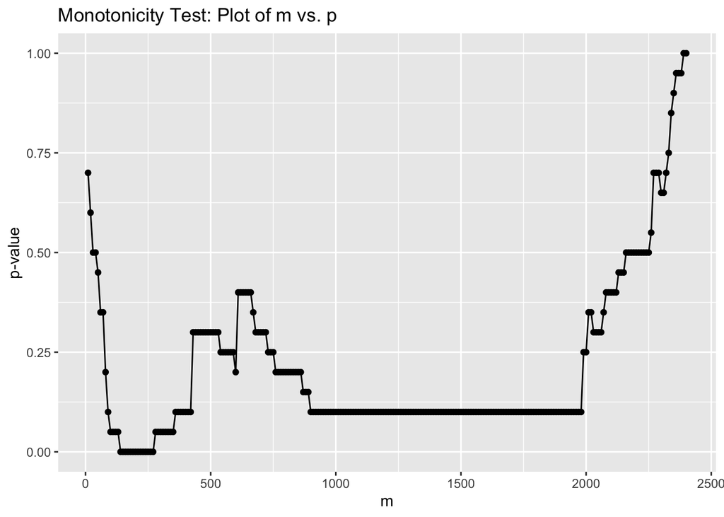

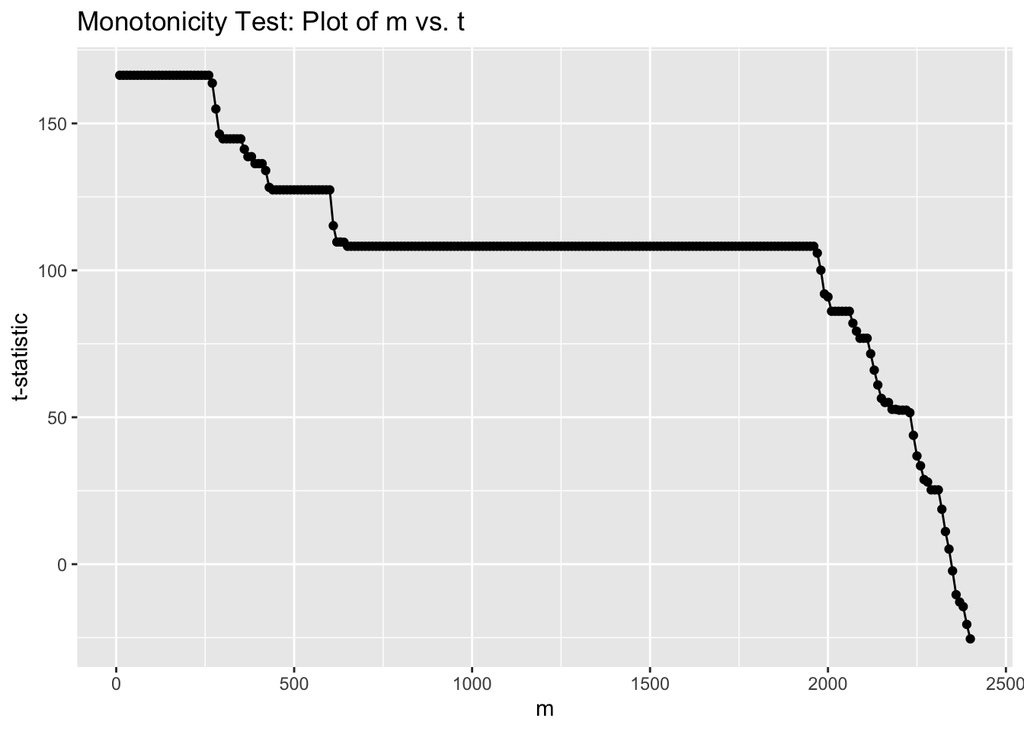

```r
plot(res)
```